# Introduction to motif manipulation with the “universalmotif” package

Benjamin Tremblay

University of Waterloo, Waterloo, Canada

b2tremblay@uwaterloo.ca

17 août 2018

#### Abstract

Import, manipulate, and export motifs with R.

# 1 Installation

```r
if (!requireNamespace("BiocManager", quietly = TRUE))
  install.packages("BiocManager")
BiocManager::install("universalmotif")
```

# 2 Introduction to sequence motifs

Motifs are a more practical representation of consensus elements in biological sequences, allowing for a more detailed description of the variability at each site (see Stormo 2000). There are a number of ways of representing motifs; four types are available here. All of these can be stored using the same `universalmotif` class. Unfortunately, the naming conventions for the various motif types are not unanimous. In order to provide a simple interface to the various types, in this package they are referred to as Position Count Matrix (PCM), Position Probability Matrix (PPM), Position Weight Matrix (PWM), and Information Content Matrix (ICM).

These four types will be described here. Furthermore, the actual code used to go between these types can be see in `?utilities`.

## 2.1 Position count matrices

Also known as position frequency matrices, these are typically the most basic representation of a motif. Simply, for each position the total counts of letters is shown. For example, the following sequences:

Table 1: Starting sequences

| # | Sequence |
| --- | --- |
| 1 | AAGAAT |
| 2 | ATCATA |
| 3 | AAGTAA |
| 4 | AACAAA |
| 5 | ATTAAA |
| 6 | AAGAAT |

… would be represented as:

Table 2: Position count matrix

| Position | 1 | 2 | 3 | 4 | 5 | 6 |
| --- | --- | --- | --- | --- | --- | --- |
| A | 6 | 4 | 0 | 5 | 5 | 4 |
| C | 0 | 0 | 2 | 0 | 0 | 0 |
| G | 0 | 0 | 3 | 0 | 0 | 0 |
| T | 0 | 2 | 1 | 1 | 1 | 2 |

*(Note that all positions sum to 6, the initial number of sequences.)*

## 2.2 Position probability matrices

Also sometimes known as position frequency matrices and position weight matrices, these represent the probabilities for each letter at each position. Using the previous motif (table 2) as an example, the following formula would be used to calculate the probability of each letter *N* at each individual position:

$$\begin{equation}
Prob_N = \frac{Counts_N}{Counts_{Total}}
\tag{1}
\end{equation}$$

This leads to the following motif representation:

Table 3: Position probability matrix

| Position | 1 | 2 | 3 | 4 | 5 | 6 |
| --- | --- | --- | --- | --- | --- | --- |
| A | 1.00 | 0.67 | 0.00 | 0.83 | 0.83 | 0.66 |
| C | 0.00 | 0.00 | 0.33 | 0.00 | 0.00 | 0.00 |
| G | 0.00 | 0.00 | 0.50 | 0.00 | 0.00 | 0.00 |
| T | 0.00 | 0.33 | 0.17 | 0.17 | 0.17 | 0.33 |

*(Note that all positions sum to 1.)*

From this type of representation, the probability of any combination of letters can be calculated. For example, the probability for AAGAAA is about 15%. However, when starting from a small pool of sequences, many zeroes can appear in the PPM; meaning that, for example, the probability of AAAAAA is currently zero. When scanning through large numbers of biological sequences, throwing away combinations of letters such as these can be undesirable, as for example mimatches can be quite common in transcription factor binding sites; this can be fixed by adding a ‘pseudocount’. Usually a small number such as 1, it is introduced into the PCM to PPM caculation:

$$\begin{equation}
Prob_N = \frac{Counts_N + \frac{Pseudocount}{length_N}}{Counts_{Total} + Pseudocount}
\tag{2}
\end{equation}$$

In this equation, the pseudocount is added to the top and bottom of the fraction. However for the top fraction, which is specific to each letter, the pseudocount is divided by the total number of letters (in the case of DNA, 4). This then generates the following motif:

Table 4: Position probability matrix with a pseudocount of 1

| Position | 1 | 2 | 3 | 4 | 5 | 6 |
| --- | --- | --- | --- | --- | --- | --- |
| A | 0.892 | 0.610 | 0.036 | 0.750 | 0.750 | 0.610 |
| C | 0.036 | 0.035 | 0.320 | 0.035 | 0.035 | 0.035 |
| G | 0.036 | 0.035 | 0.464 | 0.035 | 0.035 | 0.035 |
| T | 0.036 | 0.320 | 0.180 | 0.180 | 0.180 | 0.320 |

Now, though unlikely, it is no longer considered impossible for the sequence AAAAAA to exist as part of this motif. Since the total number of sequences in this case is quite low, the pseudocount can have a large impact on the values within the matrix; this impact decreases as the number of sequences increases. Of course, this can also be changed by using different pseudocounts.

## 2.3 Position weight matrices

The position weight matrix, also known as position-specific weight matrix, position-specific scoring matrix, and logodds scoring matrix, was first proposed by Stormo et al. (1982). In this case for each position, every letter has a ‘score’; this can be used to evaluate how well a sequence matches a motif. Though there can be multiple ways of calculating these scores, the most common method is to calculate the log of each probability, correcting for background frequencies. This results in the following calculation:

$$\begin{equation}
Score_N = \log_{2}\left(\frac{Prob_N}{ProbBkg_N}\right)
\tag{3}
\end{equation}$$

Using this equation, the log of fractions where the probability of a certain letter in a sequence is higher than that of the background probability of that letter result in positive scores, and vice versa for negative scores. Using the table 3 motif and assuming a uniform background frequency (i.e. the probability of each of the four letters is 0.25), this results in the following PWM:

Table 5: Position weight matrix

| Position | 1 | 2 | 3 | 4 | 5 | 6 |
| --- | --- | --- | --- | --- | --- | --- |
| A | 2 | 1.425 | -Inf | 1.737 | 1.737 | 1.415 |
| C | -Inf | -Inf | 0.415 | -Inf | -Inf | -Inf |
| G | -Inf | -Inf | 1.000 | -Inf | -Inf | -Inf |
| T | -Inf | 0.415 | -0.585 | -0.585 | -0.595 | 0.415 |

*(Note that the position totals no longer have equal sums.)*

In order to score a sequence, add up the score for the letters at the specific positions; for example AAGAAA has a score of 9.31. However, similar to with PPMs, if starting from a small pool of sequences the sequence AAAAAA could never be recovered using this motif model, with a score of -Inf. This can be avoided simply by starting from a pseudocount-adjusted PPM. Using the table 4 motif, this becomes:

Table 6: Position weight matrix with a pseudocount of 1

| Position | 1 | 2 | 3 | 4 | 5 | 6 |
| --- | --- | --- | --- | --- | --- | --- |
| A | 1.840 | 1.280 | -2.807 | 1.585 | 1.585 | 1.280 |
| C | -2.807 | -2.807 | 0.363 | -2.807 | -2.807 | -2.807 |
| G | -2.807 | -2.807 | 0.893 | -2.807 | -2.807 | -2.807 |
| T | -2.807 | 0.363 | -0.485 | -0.485 | -0.485 | 0.363 |

Now, the score for AAGAA is 8.46, and the score for AAAAAA is 4.76. Though the score for the latter is low, it is no longer -Inf as a result of one mismatch.

When searching for instances of this motif using this scoring system, one more consideration is needed: a minimum score. For example, both sequences AAGAAA and ATTTTT have positive scores; but one is much higher than the other. Should ATTTTT then be discarded? In order to answer this a threshold is set; typically this is a certain percent of the highest possible score. For example, in the table 6 motif, the highest possible score is 8.46; using a threshold of 25%, the minimum score then becomes 2.115. This means that ATTTTT, with a score of 1.112, would indeed be discarded.

Other methods for determining the minimum score include starting from P-values. The package *TFMPvalue* for example can calculate minimum scores from P-values, using the algorithm described by Touzet and Varre (2007).

## 2.4 Information content matrices

Finally, the information content matrix (Schneider et al. 1986; Schneider and Stephens 1990). This type aims to include another consideration: are some positions more important than others? To explore this, let us consider the table 3 motif. This matrix can be represented as a sequence logo using the *seqLogo* package:

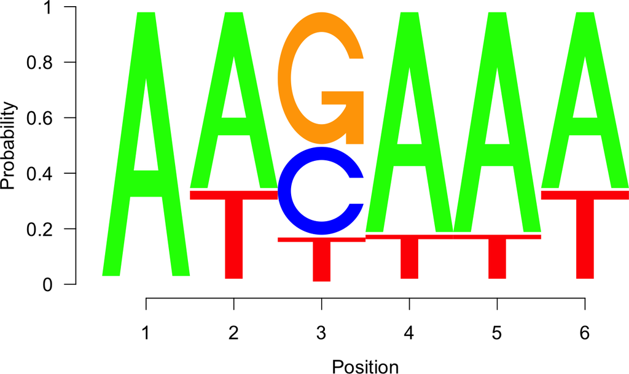

Figure 1: Sequence logo of a PPM

In this case, the height of the letters represent their probabilities at each position. However, when represented as an ICM, the sequence logo then resembles:

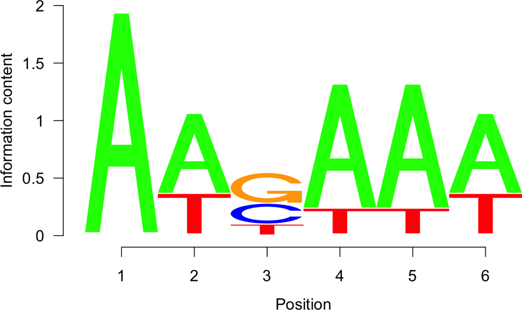

Figure 2: Sequence logo of an ICM

Now, the total height of each position is scaled using the total *information* at that position. Simply put, the total information of each position is an indication of the level of conservation; in the example motif, the first position is highly conserved, always being the letter A, whereas the third position is less so conserved, as the probabilities for any one letter are quite lower.

For every position, the letter heights are calculated as the total possible information content (IC) or maximum uncertainty, then subtracting that positions’ actual uncertainty (Schneider et al. 1986; Schneider and Stephens 1990). This calculation is based on Shannon’s entropy (Shannon 1948), with the final values representing ‘bits’ (Schneider 1991). The total IC is based on alphabet length, using the following equation:

$$\begin{equation}
IC_{total} = \log_{2}(length_N)
\tag{4}
\end{equation}$$

For DNA motifs which have an alphabet length of 4, the total IC is 2. To calculate the positions’ actual uncertainty, the following equation is used:

$$\begin{equation}
Uncertainty = - \sum_{N=A}^{T} Prob_N \times{} \log_{2}(Prob_N)
\tag{5}
\end{equation}$$

Where the position uncertainty is the sum of the uncertainty of all alphabet letters (A, C, G, and T). To calculate the final information content:

$$\begin{equation}
IC_{position} = IC_{total} - Uncertainty
\tag{6}
\end{equation}$$

In the original implementation described by Schneider et al. (1986), an additional error correction factor is included to account for sample size. This correction is rarely used however, but can be incorporated as such:

$$\begin{equation}
IC_{position} = IC_{total} - [ Uncertainty + E_{corr} ]
\tag{7}
\end{equation}$$

The details for calculating this factor will not be covered here; refer to Schneider et al. (1986). The *TFBSTools* package offers the ability to incorporate this error correction.

Finally, to get the height of each letter at each position, the final IC is multiplied by the letter and position probabilities:

$$\begin{equation}
IC_N = Prob_N \times{} IC_{position}
\tag{8}
\end{equation}$$

Using the above equations, the table 3 motif then becomes:

Table 7: Information content matrix

| Position | 1 | 2 | 3 | 4 | 5 | 6 |
| --- | --- | --- | --- | --- | --- | --- |
| A | 2.000 | 0.721 | 0.000 | 1.125 | 1.125 | 0.721 |
| C | 0.000 | 0.000 | 0.180 | 0.000 | 0.000 | 0.000 |
| G | 0.000 | 0.000 | 0.270 | 0.000 | 0.000 | 0.000 |
| T | 0.000 | 0.361 | 0.090 | 0.225 | 0.225 | 0.361 |

*(Note that none of the positions have a sum larger than 2.)*

An alternative to representing information content as Shannon’s entropy is relative entropy, or Kullback-Leibler divergence (Kullback and Leibler 1951). While IC as Shannon’s entropy has the advantage of having a consistent maximum IC for every position, it does not take into account non-uniform background frequencies. Relative entropy on the other hand will take this into account, but all positions no longer share the same maximum IC. To calculate relative entropy:

$$\begin{equation}
IC_N = Prob_N \times{} \log_{2}\left(\frac{Prob_N}{ProbBkg_N}\right)
\tag{9}
\end{equation}$$

Using this equation can lead to IC less than zero; these values are not allowed, so they are simply replaced with zero. With this equation and assuming uniform background frequencies, the table 3 motif becomes:

Table 8: Information content matrix as relative divergence

| Position | 1 | 2 | 3 | 4 | 5 | 6 |
| --- | --- | --- | --- | --- | --- | --- |
| A | 1.640 | 0.777 | 0.000 | 1.190 | 1.190 | 0.777 |
| C | 0.000 | 0.000 | 0.177 | 0.000 | 0.000 | 0.000 |
| G | 0.000 | 0.000 | 0.415 | 0.000 | 0.000 | 0.000 |
| T | 0.000 | 0.177 | 0.090 | 0.000 | 0.000 | 0.117 |

This motif would look significantly different with non-uniform background frequences. For example, starting from the following background frequencies: `c(A = 0.4, C = 0.1, G = 0.1, T= 0.4)`, the motif resembles:

Table 9: Information content matrix as relative divergence with a non-uniform background.

| Position | 1 | 2 | 3 | 4 | 5 | 6 |
| --- | --- | --- | --- | --- | --- | --- |
| A | 1.030 | 0.366 | 0.000 | 0.680 | 0.680 | 0.366 |
| C | 0.000 | 0.000 | 0.541 | 0.000 | 0.000 | 0.000 |
| G | 0.000 | 0.000 | 1.028 | 0.000 | 0.000 | 0.000 |
| T | 0.000 | 0.000 | 0.090 | 0.000 | 0.000 | 0.000 |

# 3 The universalmotif class and conversion utilities

## 3.1 The universalmotif class

The *universalmotif* package stores motifs using the `universalmotif` class. The most basic `universalmotif` object exposes the ‘name’, ‘alphabet’, ‘type’, ‘type’, ‘strand’, ‘icscore’, ‘consensus’, and ‘motif’ slots; furthermore, the ‘pseudocount’ and ‘bkg’ slots are also stored but not shown. `universalmotif` class motifs can be PCM, PPM, PWM, or ICM type.

```r
library(universalmotif)
data(examplemotif)
examplemotif
```

```
#>
#>        Motif name:   motif
#>          Alphabet:   DNA
#>              Type:   PPM
#>           Strands:   +-
#>          Total IC:   14
#>         Consensus:   TATAWAW
#>
#>   T A T A   W A   W
#> A 0 1 0 1 0.5 1 0.5
#> C 0 0 0 0 0.0 0 0.0
#> G 0 0 0 0 0.0 0 0.0
#> T 1 0 1 0 0.5 0 0.5
```

Exposing the motif class with `str` shows the other available slots:

```
#> Formal class 'universalmotif' [package "universalmotif"] with 19 slots
#>   ..@ name       : chr "motif"
#>   ..@ altname    : chr(0)
#>   ..@ family     : chr(0)
#>   ..@ organism   : chr(0)
#>   ..@ motif      : num [1:4, 1:7] 0 0 0 1 1 0 0 0 0 0 ...
#>   .. ..- attr(*, "dimnames")=List of 2
#>   .. .. ..$ : chr [1:4] "A" "C" "G" "T"
#>   .. .. ..$ : chr [1:7] "T" "A" "T" "A" ...
#>   ..@ alphabet   : chr "DNA"
#>   ..@ type       : chr "PPM"
#>   ..@ icscore    : num 14
#>   ..@ nsites     : num(0)
#>   ..@ pseudocount: num 0
#>   ..@ bkg        : num [1:4] 0.25 0.25 0.25 0.25
#>   ..@ bkgsites   : num(0)
#>   ..@ consensus  : chr "TATAWAW"
#>   ..@ strand     : chr "+-"
#>   ..@ pval       : num(0)
#>   ..@ qval       : num(0)
#>   ..@ eval       : num(0)
#>   ..@ multifreq  : list()
#>   ..@ extrainfo  : chr(0)
```

The other slots will be shown once filled:

```r
library(universalmotif)
data(examplemotif)

## The various slots can be accessed individually using `[`
examplemotif["consensus"]
```

```
#> consensus
#> "TATAWAW"
```

```r
## To change a slot, use `[<-`
examplemotif["family"] <- "My motif family"
examplemotif
```

```
#>
#>        Motif name:   motif
#>            Family:   My motif family
#>          Alphabet:   DNA
#>              Type:   PPM
#>           Strands:   +-
#>          Total IC:   14
#>         Consensus:   TATAWAW
#>
#>   T A T A   W A   W
#> A 0 1 0 1 0.5 1 0.5
#> C 0 0 0 0 0.0 0 0.0
#> G 0 0 0 0 0.0 0 0.0
#> T 1 0 1 0 0.5 0 0.5
```

Though the slots can easily be changed manually with `[<-`, a number of safeguards have been put in place for some of the slots which will prevent incorrect values from being introduced.

```r
library(universalmotif)
data(examplemotif)

## The consensus slot is dependent on the motif matrix
examplemotif["consensus"]
```

```
#> consensus
#> "TATAWAW"
```

```r
## Changing this would mean it no longer matches the motif
examplemotif["consensus"] <- "GGGAGAG"
```

```
#> Error in .local(x, i, ..., value): consensus string for DNA motifs is generated automatically
```

```r
## Another example:
examplemotif["strand"] <- "x"
```

```
#> Error in validObject(x): invalid class "universalmotif" object: motif 'strand' must be either '+', '-', or '+-'
```

```r
## Of course, this can be circumvented by simply using `@`; do this at your
## own risk. Trying to use a motif with an incorrectly filled slot will likely
## cause other universalmotif functions to fail.
examplemotif@strand <- "x"
examplemotif
```

```
#>
#>        Motif name:   motif
#>          Alphabet:   DNA
#>              Type:   PPM
#>           Strands:   x
#>          Total IC:   14
#>         Consensus:   TATAWAW
#>
#>   T A T A   W A   W
#> A 0 1 0 1 0.5 1 0.5
#> C 0 0 0 0 0.0 0 0.0
#> G 0 0 0 0 0.0 0 0.0
#> T 1 0 1 0 0.5 0 0.5
```

Below the exposed metadata slots, the actual ‘motif’ matrix is shown. Each position is its’ own column; row names showing the alphabet letters, and the column names showing the consensus letter at each position.

## 3.2 Converting to and from another package’s class

The *universalmotif* package aims to unify most of the motif-related Bioconductor packages by providing the `convert_motif` function. This allows for easy transition between supported packages (see `?convert_motif` for a complete list of supported packages).

```r
library(universalmotif)
data(examplemotif)
suppressPackageStartupMessages(library(TFBSTools))
data(MA0003.2)
suppressPackageStartupMessages(library(MotifDb))

## convert from a universalmotif to another
convert_motifs(examplemotif, "TFBSTools-PWMatrix")
```

```
#> An object of class PWMatrix
#> ID:
#> Name: motif
#> Matrix Class: Unknown
#> strand: *
#> Pseudocounts: 0.8
#> Tags:
#> list()
#> Background:
#>    A    C    G    T
#> 0.25 0.25 0.25 0.25
#> Matrix:
#>        T      A      T      A       W      A       W
#> A -6.977  1.991 -6.977  1.991  0.9943  1.991  0.9943
#> C -6.977 -6.977 -6.977 -6.977 -6.9773 -6.977 -6.9773
#> G -6.977 -6.977 -6.977 -6.977 -6.9773 -6.977 -6.9773
#> T  1.991 -6.977  1.991 -6.977  0.9943 -6.977  0.9943
```

```r
## convert to universalmotif
convert_motifs(MA0003.2)
```

```
#>
#>        Motif name:   TFAP2A
#>    Alternate name:   MA0003.2
#>            Family:   Helix-Loop-Helix
#>          Organism:   9606
#>          Alphabet:   DNA
#>              Type:   PCM
#>           Strands:   +
#>          Total IC:   12.9
#>         Consensus:   NNNNGCCYSAGGGCA
#>      Target sites:   5098
#>        Extra info:   centrality_logp: -4343
#>                      family: Helix-Loop-Helix
#>                      medline: 10497269
#>                      pazar_tf_id: TF0000002
#>                      source: ENCODE
#>                      tax_group: vertebrates
#>                      tfbs_shape_id: 264
#>                      type: ChIP-seq
#>                      collection: CORE
#>                      species: 9606
#>                      acc: P05549
#>
#>      N    N    N    N    G    C    C    Y    S    A    G    G    G    C    A
#> A 1387 2141  727 1517   56    0    0   62  346 3738  460    0  116  451 3146
#> C 1630 1060 1506  519 1199 5098 4762 1736 2729  236    0    0 1443 3672  690
#> G  851  792  884  985 3712    0    0   85 1715  920 4638 5098 3455  465  168
#> T 1230 1105 1981 2077  131    0  336 3215  308  204    0    0   84  510 1094
```

```r
## convert between two packages
convert_motifs(MotifDb[1], "TFBSTools-ICMatrix")
```

```
#> [[1]]
#> An object of class ICMatrix
#> ID: M0001_1.02
#> Name: ABF1
#> Matrix Class: Unknown
#> strand: *
#> Pseudocounts: 0.8
#> Schneider correction: FALSE
#> Tags:
#> list()
#> Background:
#>    A    C    G    T
#> 0.25 0.25 0.25 0.25
#> Matrix:
#>         T       T       A       T       C       A       C       T
#> A 0.02049 0.02049 1.65964 0.02049 0.02049 1.65964 0.02049 0.02049
#> C 0.02049 0.02049 0.02049 0.02049 1.65964 0.02049 1.65964 0.02049
#> G 0.02049 0.02049 0.02049 0.02049 0.02049 0.02049 0.02049 0.02049
#> T 1.65964 1.65964 0.02049 1.65964 0.02049 0.02049 0.02049 1.65964
```

The `convert_motifs` function is embedded in most of the *universalmotif* functions, meaning that compatible motif classes from other packages can be used without needed to convert them first.

# 4 Importing and exporting motifs

## 4.1 Importing

The *universalmotif* package offers a number of `read_` functions to allow for easy import of various motif formats. These include:

- `read_cisbp`: CIS-BP (Weirauch et al. 2014)
- `read_homer`: HOMER (Heinz et al. 2010)
- `read_jaspar`: JASPAR (Khan et al. 2018)
- `read_meme`: MEME (Bailey et al. 2009)
- `read_transfac`: TRANSFAC (Wingender et al. 1996)
- `read_uniprobe`: UniPROBE (Hume et al. 2015)

These functions should work natively with these formats, but if you are generating your own motifs in one of these formats than it must adhere quite strictly to the format. An example of each of these is included in this package; see `system.file("extdata", package="universalmotif")`.

Additionally, the generic `read_matrix` function can read simply-formatted motif files; each motif can have a header and a motif matrix.

## 4.2 Exporting

Compatible motif classes can be written to disk using:

- `write_homer`
- `write_jaspar`
- `write_matrix`
- `write_meme`
- `write_transfac`

The `write_matrix` function, similar to its’ `read_matrix` counterpart, can write motifs as simple matrices with an optional header.

# 5 Modifying motifs and related functions

## 5.1 Converting motif type

Any `universalmotif` object can transition between PCM, PPM, PWM, and ICM types seamlessly using the `convert_type` function. The only exception to this is if the ICM calculation is performed with sample correction, or as relative entropy. If this occurs, then back conversion to another type will be inaccurate.

```r
library(universalmotif)
data(examplemotif)

## This motif is currently a PPM:
examplemotif["type"]
```

```
#>  type
#> "PPM"
```

```r
## When converting to PCM, the 'nsites' slot is needed to tell it how
## many sequences it originated from. If empty, 100 is used.
convert_type(examplemotif, "PCM")
```

```
#>
#>        Motif name:   motif
#>          Alphabet:   DNA
#>              Type:   PCM
#>           Strands:   +-
#>          Total IC:   14
#>         Consensus:   TATAWAW
#>
#>     T   A   T   A  W   A  W
#> A   0 100   0 100 50 100 50
#> C   0   0   0   0  0   0  0
#> G   0   0   0   0  0   0  0
#> T 100   0 100   0 50   0 50
```

```r
## For converting to PWM, the 'pseudocount' slot is used to determine if any
## correction should be applied:
examplemotif["pseudocount"]
```

```
#> pseudocount
#>           0
```

```r
convert_type(examplemotif, "PWM")
```

```
#>
#>        Motif name:   motif
#>          Alphabet:   DNA
#>              Type:   PWM
#>           Strands:   +-
#>          Total IC:   14
#>         Consensus:   TATAWAW
#>
#>      T    A    T    A    W    A    W
#> A -Inf    2 -Inf    2    1    2    1
#> C -Inf -Inf -Inf -Inf -Inf -Inf -Inf
#> G -Inf -Inf -Inf -Inf -Inf -Inf -Inf
#> T    2 -Inf    2 -Inf    1 -Inf    1
```

```r
## You can either change the 'pseudocount' slot manually beforehand, or pass
## one to 'convert_type'
convert_type(examplemotif, "PWM", pseudocount = 1)
```

```
#>
#>        Motif name:   motif
#>          Alphabet:   DNA
#>              Type:   PWM
#>           Strands:   +-
#>          Total IC:   14
#>         Consensus:   TATAWAW
#>
#>       T     A     T     A      W     A      W
#> A -6.66  1.99 -6.66  1.99  0.993  1.99  0.993
#> C -6.66 -6.66 -6.66 -6.66 -6.658 -6.66 -6.658
#> G -6.66 -6.66 -6.66 -6.66 -6.658 -6.66 -6.658
#> T  1.99 -6.66  1.99 -6.66  0.993 -6.66  0.993
```

```r
## There are a couple of additional options for ICM conversion:
## 'nsize_correction' and 'relative_entropy'. The former uses the
## TFBSTools:::schneider_correction function for sample size correction.
## The latter uses the 'bkg' slot to calculate information content.
examplemotif["nsites"] = 10
convert_type(examplemotif, "ICM", nsize_correction = FALSE)
```

```
#>
#>        Motif name:   motif
#>          Alphabet:   DNA
#>              Type:   ICM
#>           Strands:   +-
#>          Total IC:   14
#>         Consensus:   TATAWAW
#>      Target sites:   10
#>
#>   T A T A   W A   W
#> A 0 2 0 2 0.5 2 0.5
#> C 0 0 0 0 0.0 0 0.0
#> G 0 0 0 0 0.0 0 0.0
#> T 2 0 2 0 0.5 0 0.5
```

```r
convert_type(examplemotif, "ICM", nsize_correction = TRUE)
```

```
#>
#>        Motif name:   motif
#>          Alphabet:   DNA
#>              Type:   ICM
#>           Strands:   +-
#>          Total IC:   14
#>         Consensus:   TATAWAW
#>      Target sites:   10
#>
#>      T    A    T    A     W    A     W
#> A 0.00 1.75 0.00 1.75 0.377 1.75 0.377
#> C 0.00 0.00 0.00 0.00 0.000 0.00 0.000
#> G 0.00 0.00 0.00 0.00 0.000 0.00 0.000
#> T 1.75 0.00 1.75 0.00 0.377 0.00 0.377
```

```r
examplemotif["bkg"] = c(0.4, 0.1, 0.1, 0.4)
convert_type(examplemotif, "ICM", relative_entropy = TRUE)
```

```
#>
#>        Motif name:   motif
#>          Alphabet:   DNA
#>              Type:   ICM
#>           Strands:   +-
#>          Total IC:   14
#>         Consensus:   TATAWAW
#>      Target sites:   10
#>
#>      T    A    T    A     W    A     W
#> A 0.00 1.32 0.00 1.32 0.161 1.32 0.161
#> C 0.00 0.00 0.00 0.00 0.000 0.00 0.000
#> G 0.00 0.00 0.00 0.00 0.000 0.00 0.000
#> T 1.32 0.00 1.32 0.00 0.161 0.00 0.161
```

## 5.2 Comparing and merging motifs

There a few functions available in other Bioconductor packages which allow for motif comparison. These include `PWMSimlarity` (*TFBSTools*), `motifDistances` (*MotIV*), and `motifSimilarity` (*PWMEnrich*). Unfortunately these functions are not designed for comparing large numbers of motifs, and can result in long run times. The *universalmotif* package aims to fix this by providing the `compare_motifs` function. Using the *TFBSTools* implementation as a source, the function has been rewritten in C++ and allows for comparing thousands of motifs in seconds.

```r
library(universalmotif)
library(MotifDb)

## No need to convert class, most universalmotif functions will do it
## automatically
motifs.dist <- compare_motifs(MotifDb[1:5])
as.dist(motifs.dist)
```

```
#>              ABF1    AFT1    AFT2 PK19363.1
#> AFT1      0.32787
#> AFT2      0.52563 0.66835
#> PK19363.1 0.09471 0.39282 0.51457
#> ORA59     0.01415 0.46587 0.45491   0.90229
```

```r
## If comparing thousands of motifs, multicore usage is made available via
## the 'BiocParallel' package

library(BiocParallel)
parallel.opt <- bpparam()
## To add a progress bar:
# parallel.opt$progressBar <- TRUE
motifs.dist <- compare_motifs(MotifDb[1:5], BPPARAM = parallel.opt)
```

Additionally, *universalmotif* provides the `merge_motifs` function. This first finds the best alignment of input motifs before merging.

```r
library(universalmotif)
library(MotifDb)

motifs <- convert_motifs(MotifDb[1:5])

## Two merging methods are offered: via the 'msa' package, and via the
## 'motifStack' package.
# merge_motifs(motifs, method = "msa")
# merge_motifs(motifs, method = "motifStack")
```

## 5.3 Multi-letter information

Though PCM/PPM/PWM/ICM type motifs are still widely used today, a few ‘next generation’ motif formats have been proposed. These wish to add another layer of information to motifs: nucleotide interdependence. To illustrate this, consider the following sequences:

Table 10: Example sequences

| # | Sequence |
| --- | --- |
| 1 | CAAAACC |
| 2 | CAAAACC |
| 3 | CAAAACC |
| 4 | CTTTTCC |
| 5 | CTTTTCC |
| 6 | CTTTTCC |

This becomes the following PPM:

Table 11: Position probability matrix

| Position | 1 | 2 | 3 | 4 | 5 | 6 | 7 |
| --- | --- | --- | --- | --- | --- | --- | --- |
| A | 0.0 | 0.5 | 0.5 | 0.5 | 0.5 | 0.0 | 0.0 |
| C | 1.0 | 0.0 | 0.0 | 0.0 | 0.0 | 1.0 | 1.0 |
| G | 0.0 | 0.0 | 0.0 | 0.0 | 0.0 | 0.0 | 0.0 |
| T | 0.0 | 0.5 | 0.5 | 0.5 | 0.5 | 0.0 | 0.0 |

Based on the PPM representation, all three of CAAAACC, CTTTTCC, and CTATACC are equally likely. Though looking at the starting sequences, should CTATACC really be considered so? For transcription factor binding sites, generally the answer is no. By incorporating this type of information into the motif, this can allow for increased accuracy in motif searching. A few implementations of this include: TFFM by Mathelier and Wasserman (2013), BaMM by Siebert and Soding (2016), and KSM by Guo et al. (2018).

The *universalmotif* package implements its’ own, much simplified, version of this concept. Plainly, the standard PPM has been extended to include k-letter frequencies, with k being any number higher than 1. For example, the 2-letter version of the table 11 motif would be:

Table 12: 2-letter probability matrix

| Position | 1 | 2 | 3 | 4 | 5 | 6 |
| --- | --- | --- | --- | --- | --- | --- |
| AA | 0.0 | 0.5 | 0.5 | 0.5 | 0.0 | 0.0 |
| AC | 0.0 | 0.0 | 0.0 | 0.0 | 0.5 | 0.0 |
| AG | 0.0 | 0.0 | 0.0 | 0.0 | 0.0 | 0.0 |
| AT | 0.0 | 0.0 | 0.0 | 0.0 | 0.0 | 0.0 |
| CA | 0.5 | 0.0 | 0.0 | 0.0 | 0.0 | 0.0 |
| CC | 0.0 | 0.0 | 0.0 | 0.0 | 0.0 | 1.0 |
| CG | 0.0 | 0.0 | 0.0 | 0.0 | 0.0 | 0.0 |
| CT | 0.5 | 0.0 | 0.0 | 0.0 | 0.0 | 0.0 |
| GA | 0.0 | 0.0 | 0.0 | 0.0 | 0.0 | 0.0 |
| GC | 0.0 | 0.0 | 0.0 | 0.0 | 0.0 | 0.0 |
| GG | 0.0 | 0.0 | 0.0 | 0.0 | 0.0 | 0.0 |
| GT | 0.0 | 0.0 | 0.0 | 0.0 | 0.0 | 0.0 |
| TA | 0.0 | 0.0 | 0.0 | 0.0 | 0.0 | 0.0 |
| TC | 0.0 | 0.0 | 0.0 | 0.0 | 0.5 | 0.0 |
| TG | 0.0 | 0.0 | 0.0 | 0.0 | 0.0 | 0.0 |
| TT | 0.0 | 0.5 | 0.5 | 0.5 | 0.0 | 0.0 |

This format shows the probability of each letter combined with the probability of the letter in the next position. The seventh column has been dropped, since it is not needed; the information in the sixth column is sufficient, and there is no eighth position to draw 2-letter probabilities from. Now, the probability of getting CTATACC is no longer equal to CTTTTCC and CAAAACC. This information is kept in the `multifreq` slot of `universalmotif` class motifs. To add this information, use the `add_multifreq` function.

```r
library(universalmotif)
library(Biostrings)

motif <- create_motif("CWWWWCC", nsites = 6)  ## -> see next section
sequences <- DNAStringSet(rep(c("CAAAACC", "CTTTTCC"), 3))
motif.k2 <- add_multifreq(motif, sequences, add.k = 2)
motif.k2
```

```
#>
#>        Motif name:   motif
#>          Alphabet:   DNA
#>              Type:   PPM
#>           Strands:   +-
#>          Total IC:   10
#>         Consensus:   CWWWWCC
#>      Target sites:   6
#>    k-letter freqs:   2
#>
#>   C   W   W   W   W C C
#> A 0 0.5 0.5 0.5 0.5 0 0
#> C 1 0.0 0.0 0.0 0.0 1 1
#> G 0 0.0 0.0 0.0 0.0 0 0
#> T 0 0.5 0.5 0.5 0.5 0 0
```

# 6 Motif creation

Though `universalmotif` class motifs can be created using the `new` constructor, the *universalmotif* package provides the `create_motif` function which aims to provide a simpler interface to motif creation. The `universalmotif` class was designed to work natively with DNA, RNA, and amino acid motifs. Despite this, it can handle any custom alphabet just as easily.

The `create_motif` function will be introduced briefly here; see `?create_motif` for details.

## 6.1 From a PCM/PPM/PWM/ICM matrix

Should you wish to make use of the *universalmotif* functions starting from a unsupported motif class, you can instead create `universalmotif` class motifs using the `create_motif` function.

```r
motif.matrix <- matrix(c(0.7, 0.1, 0.1, 0.1,
                         0.7, 0.1, 0.1, 0.1,
                         0.1, 0.7, 0.1, 0.1,
                         0.1, 0.7, 0.1, 0.1,
                         0.1, 0.1, 0.7, 0.1,
                         0.1, 0.1, 0.7, 0.1,
                         0.1, 0.1, 0.1, 0.7,
                         0.1, 0.1, 0.1, 0.7), nrow = 4)
motif <- create_motif(motif.matrix, alphabet = "RNA", name = "My motif",
                      pseudocount = 1, nsites = 20, strand = "+")
## The 'type', 'icscore' and 'consensus' slots will be filled for you
motif
```

```
#>
#>        Motif name:   My motif
#>          Alphabet:   RNA
#>              Type:   PPM
#>           Strands:   +
#>          Total IC:   4.677
#>         Consensus:   AACCGGUU
#>      Target sites:   20
#>
#>     A   A   C   C   G   G   U   U
#> A 0.7 0.7 0.1 0.1 0.1 0.1 0.1 0.1
#> C 0.1 0.1 0.7 0.7 0.1 0.1 0.1 0.1
#> G 0.1 0.1 0.1 0.1 0.7 0.7 0.1 0.1
#> U 0.1 0.1 0.1 0.1 0.1 0.1 0.7 0.7
```

## 6.2 From sequences or character strings

If all you have is a particular consensus sequence in mind, you can easily create a full motif using `create_motif`. This can be convenient if you’d like to create a motif to use with an external program such as MEME or HOMER.

```r
motif <- create_motif("CCNSNGG", nsites = 50, pseudocount = 1)
```

[output not shown]

```r
## write_meme(motif, "meme_motif.txt")

motif
```

```
#>
#>        Motif name:   motif
#>          Alphabet:   DNA
#>              Type:   PPM
#>           Strands:   +-
#>          Total IC:   8.392
#>         Consensus:   CCNSNGG
#>      Target sites:   50
#>
#>        C      C    N      S    N      G      G
#> A 0.0049 0.0049 0.25 0.0049 0.25 0.0049 0.0049
#> C 0.9853 0.9853 0.25 0.4951 0.25 0.0049 0.0049
#> G 0.0049 0.0049 0.25 0.4951 0.25 0.9853 0.9853
#> T 0.0049 0.0049 0.25 0.0049 0.25 0.0049 0.0049
```

## 6.3 Generating random motifs

If you wish, it’s easy to generate random motifs:

```r
create_motif()
```

```
#>
#>        Motif name:   motif
#>          Alphabet:   DNA
#>              Type:   PPM
#>           Strands:   +-
#>          Total IC:   2.503
#>         Consensus:   BRMYHNNWGN
#>
#>        B       R      M      Y      H     N     N      W      G      N
#> A 0.0498 0.51373 0.4159 0.0149 0.3440 0.296 0.148 0.4008 0.2453 0.4051
#> C 0.2518 0.12720 0.3744 0.4043 0.2685 0.197 0.315 0.0793 0.0398 0.3007
#> G 0.3963 0.35056 0.1483 0.1654 0.0883 0.263 0.209 0.1200 0.5144 0.0854
#> T 0.3021 0.00852 0.0613 0.4154 0.2991 0.243 0.328 0.3998 0.2006 0.2088
```

```r
## You can change the probabilities:
create_motif(bkg = c(0.2, 0.4, 0.2, 0.2))
```

```
#>
#>        Motif name:   motif
#>          Alphabet:   DNA
#>              Type:   PPM
#>           Strands:   +-
#>          Total IC:   10.18
#>         Consensus:   NTCWRTGCGM
#>
#>        N      T        C        W        R        T     G        C        G
#> A 0.0182 0.0067 0.130291 3.95e-01 4.41e-01 4.41e-02 0.016 4.67e-06 3.49e-08
#> C 0.4323 0.1817 0.867537 2.61e-02 1.74e-01 6.99e-05 0.101 9.95e-01 1.72e-01
#> G 0.2357 0.1175 0.001911 1.76e-05 3.85e-01 3.41e-02 0.743 1.58e-04 8.28e-01
#> T 0.3139 0.6941 0.000261 5.79e-01 5.12e-11 9.22e-01 0.140 4.49e-03 3.29e-07
#>          M
#> A 0.411460
#> C 0.415512
#> G 0.172800
#> T 0.000227
```

```r
## With a custom alphabet:
create_motif(alphabet = "QWERTY")
```

```
#>
#>        Motif name:   motif
#>          Alphabet:   QWERTY
#>              Type:   PPM
#>           Strands:   +-
#>          Total IC:   2.52
#>
#>     [,1]   [,2]   [,3]   [,4]   [,5]   [,6]   [,7]   [,8]   [,9]  [,10]
#> E 0.2592 0.2029 0.2804 0.2015 0.0958 0.3831 0.2543 0.1220 0.1726 0.1914
#> Q 0.2369 0.2118 0.0750 0.0998 0.0855 0.0201 0.0465 0.0881 0.3348 0.2203
#> R 0.1694 0.1474 0.2201 0.2091 0.1061 0.1298 0.0617 0.3308 0.0114 0.0110
#> T 0.0248 0.1114 0.1853 0.1024 0.2271 0.1318 0.3074 0.0398 0.2708 0.3668
#> W 0.0610 0.0902 0.1531 0.1867 0.1861 0.2303 0.1475 0.3733 0.1480 0.0699
#> Y 0.2487 0.2362 0.0861 0.2005 0.2994 0.1049 0.1826 0.0460 0.0624 0.1406
```

# 7 Sequence-related functions

## 7.1 Sequence shuffling and creation

The *Biostrings* package offers an excellent suite of functions for dealing with biological sequences. The *universalmotif* package hopes to help extend these by providing the `create_sequences` and `shuffle_sequences` functions.

```r
library(universalmotif)
## library(Biostrings)
## Create some DNA sequences for use with an external program:
sequences <- create_sequences(seqnum = 500, monofreqs = c(0.3, 0.2, 0.2, 0.3))
## writeXStringSet(sequences, "bkg.fasta")

## Shuffle sequences:
## sequences <- readDNAStringSet("sequences.fasta")
sequences <- shuffle_sequences(sequences)

## Maintain dinucleotide frequencies:
sequences <- shuffle_sequences(sequences, k = 2)

## Create sequences from any starting alphabet:
sequences <- create_sequences(alphabet = "QWERTY")
sequences <- shuffle_sequences(sequences, k = 6)
```

## 7.2 Searching for motifs in sequences

There are many fantastic motif scanning and enrichment programs available, such as [HOMER](http://homer.ucsd.edu/homer/index.html) and the [MEME suite](http://meme-suite.org/) to name a couple. The *universalmotif* package does not aim to supplant these, but rather provide convenience functions for quickly scanning a few sequences without needing to leave the R environment. Furthermore, these functions allow for taking advantage of the k-letter motif format described earlier.

Two functions are provided: `scan_sequences` and `enrich_motifs`. Given a motif of length n, `scan_sequences` considers every n-length subset in a sequence and scores it using the PWM format. If it surpasses the minimum threshold, it is reported. This is case regardless of whether one is scanning with a regular motif, or using the k-letter motif format (the k-letter PPM is converted to a k-letter PWM). The second function, `enrich_motifs`, simply scans a set of target sequences, then a set of background sequences, and checks for significant enrichment.

```r
library(universalmotif)
library(Biostrings)

sequences <- create_sequences()

## Let us revisit our 2-letter motif example:
motif.k2 <- create_motif("CWWWWCC", nsites = 6)
sequences.k2 <- DNAStringSet(rep(c("CAAAACC", "CTTTTCC"), 3))
motif.k2 <- add_multifreq(motif.k2, sequences.k2, add.k = 2)

## Regular scanning:
head(scan_sequences(motif.k2, sequences, RC = TRUE, verbose = 0))
```

```
#>   motif sequence start stop score max.score score.pct   match strand
#> 1 motif        1     1    7     4        10        40 CCTAGTG      +
#> 2 motif        1     4   10     1        10        10 AGTGGGA      +
#> 3 motif        1     7   13     1        10        10 GGGACGT      +
#> 4 motif        1     8   14     1        10        10 GGACGTG      +
#> 5 motif        1    10   16     1        10        10 ACGTGTT      +
#> 6 motif        1    11   17     4        10        40 CGTGTTT      +
```

```r
## Using 2-letter information to scan:
head(scan_sequences(motif.k2, sequences, use.freq = 2, RC = TRUE, verbose = 0))
```

```
#>   motif sequence start stop  score max.score score.pct  match strand
#> 1 motif        4     1    8  3.445        19     18.13 ATTTTC      +
#> 2 motif        6    55   62  3.445        19     18.13 ATTTTC      +
#> 3 motif       10    49   56  3.445        19     18.13 GTTTTC      +
#> 4 motif       12    73   80 18.994        19     99.98 CTTTTC      +
#> 5 motif       13    53   60  2.445        19     12.87 CAAAAC      +
#> 6 motif       16    77   84  2.445        19     12.87 CAAAAC      +
```

# 8 Motif visualization

## 8.1 Motif logos

There are several packages which offer motif visualization capabilities, such as *seqLogo*, *Logolas*, *motifStack*, and *ggseqlogo*. Here I will briefly show how to use these to visualize `universalmotif` class motifs.

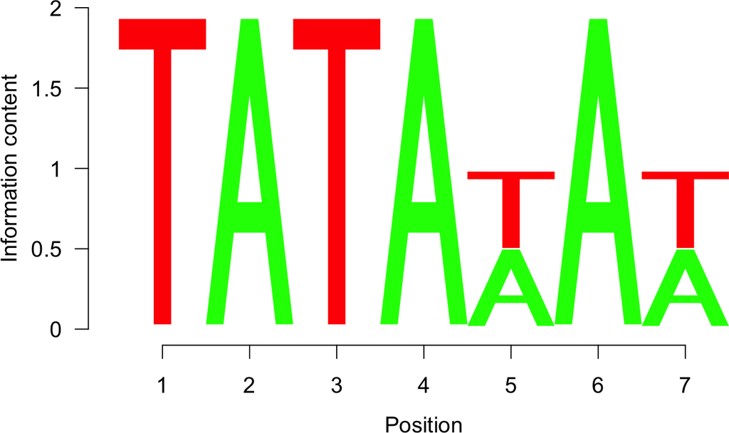

```r
library(universalmotif)
data(examplemotif)

## For all the examples, simply passing the functions a PPM is sufficient
motif <- convert_type(examplemotif, "PPM")
## Only need the matrix itself
motif <- motif["motif"]

## seqLogo:
seqLogo::seqLogo(motif)
```

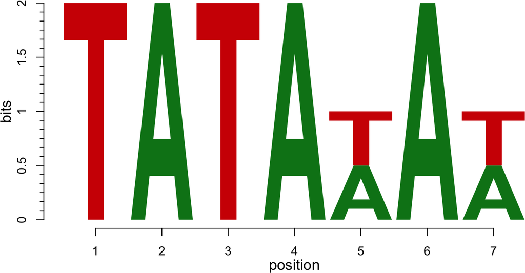

```r
## motifStack:
motifStack::plotMotifLogo(motif)
```

```r
## Logolas:
if (requireNamespace("Logolas", quietly = TRUE)) {
  colnames(motif) <- seq_len(ncol(motif))
  Logolas::logomaker(motif, type = "Logo")
}
```

```
#> color_type not provided, so switching to per_row option for
#>                color_type
#> frame width not provided, taken to be 1
#> using a background with equal probability for all symbols
```

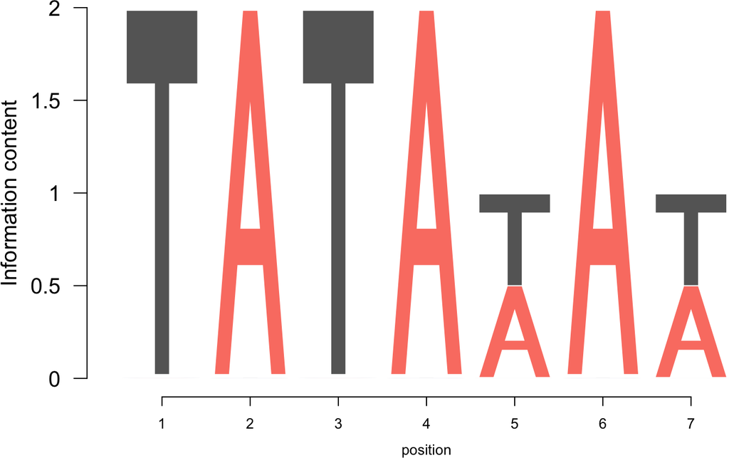

```r
## ggseqlogo:
if (requireNamespace("ggseqlogo", quietly = TRUE)) {
  ggseqlogo::ggseqlogo(motif)
}
```

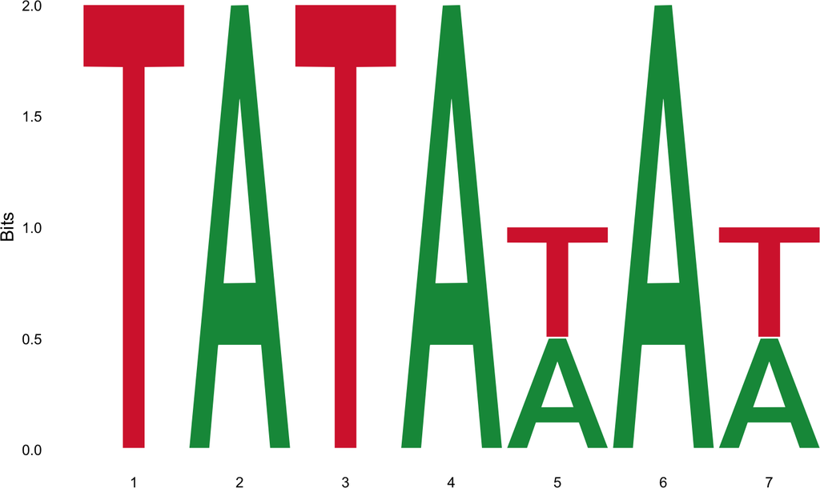

The *Logolas* and *ggseqlogo* offer many additional options for logo customization, including custom alphabets as well as manually determining the heights of each letter, via the *grid* and *ggplot2* packages respectively.

## 8.2 Motif trees with ggtree and motifStack

The *motifStack* offers a number of excellent functions for comparing motifs. Any of them can be used after using `convert_motifs`. Additionally, this package introduces the `motif_tree` function for generating basic tree-like diagrams for comparing motifs.

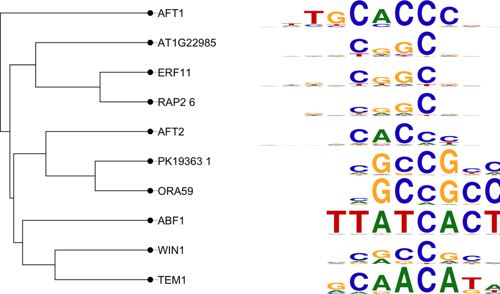

```r
library(universalmotif)
library(MotifDb)

## A simple motifStack example:
motifs <- convert_motifs(MotifDb[1:10], "motifStack-pfm")
motifStack::motifStack(motifs, layout = "phylog")
```

```r
## motif_tree is much simpler, but also much faster and allows for
## bigger trees; done via the ggtree package
motif_tree(MotifDb[301:400], layout = "daylight", linecol = "family")
```

```
#> Average angle change [1] 0.080931235825627
#> Average angle change [2] 0.02439105682278
```

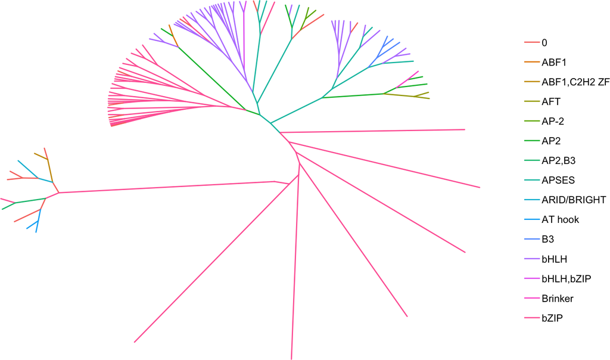

# References

Bailey, T.L., M. Boden, F.A. Buske, M. Frith, C.E. Grant, L. Clementi, J. Ren, W.W. Li, and W.S. Noble. 2009. “MEME Suite: Tools for Motif Discovery and Searching.” *Nucleic Acids Research* 37: W202–W208.

Guo, Y., K. Tian, H. Zeng, X. Guo, and D.K. Gifford. 2018. “A Novel K-Mer Set Memory (KSM) Motif Representation Improves Regulatory Variant Prediction.” *Genome Research* 28: 891–900.

Heinz, S., C. Benner, N. Spann, E. Bertolino, Y.C. Lin, P. Laslo, J.X. Cheng, C. Murre, H. Singh, and C.K. Glass. 2010. “Simple Combinations of Lineage-Determining Transcription Factors Prime Cis-Regulatory Elements Required for Macrophage and B Cell Identities.” *Molecular Cell* 38 (4): 576–89.

Hume, M.A., L.A. Barrera, S.S. Gisselbrecht, and M.L. Bulyk. 2015. “UniPROBE, Update 2015: New Tools and Content for the Online Database of Protein-Binding Microarray Data on Protein-Dna Interactions.” *Nucleic Acids Research* 43: D117–D122.

Khan, A., O. Fornes, A. Stigliani, M. Gheorghe, J.A. Castro-Mondragon, R. van der Lee, A. Bessy, et al. 2018. “JASPAR 2018: Update of the Open-Access Database of Transcription Factor Binding Profiles and Its Web Framework.” *Nucleic Acids Research* 46 (D1): D260–D266.

Kullback, S., and R. A. Leibler. 1951. “On Information and Sufficiency.” *The Annals of Mathematical Statistics* 22: 79–86.

Mathelier, A., and W.W. Wasserman. 2013. “The Next Generation of Transcription Factor Binding Site Prediction.” *PLoS Computational Biology* 9 (9): e1003214.

Schneider, T. D. 1991. “Theory of Molecular Machines. II. Energy Dissipation from Molecular Machines.” *Journal of Theoretical Biology* 148 (1): 125–37.

Schneider, T. D., and R. M. Stephens. 1990. “Sequence Logos: A New Way to Display Consensus Sequences.” *Nucleic Acids Research* 18 (20): 6097–6100.

Schneider, Thomas D., Gary D. Stormo, Larry Gold, and Andrzej Ehrenfeucht. 1986. “Information Content of Binding Sites on Nucleotide Sequences.” *Journal of Molecular Biology* 188 (3): 415–31.

Shannon, Claude E. 1948. “A Mathematical Theory of Communication.” *Bell System Technical Journal* 27 (3): 379–423.

Siebert, M., and J. Soding. 2016. “Bayesian Markov Models Consistently Outperform PWMs at Predicting Motifs in Nucleotide Sequences.” *Nucleic Acids Research* 44 (13): 6055–69.

Stormo, Gary D., Thomas D. Schneider, Larry Gold, and Andrzej Ehrenfeucht. 1982. “Use of the Perceptron Algorithm to Distinguish Translational Initiation Sites in E. coli.” *Nucleic Acids Research* 10 (9): 2997–3011.

Stormo, G. D. 2000. “DNA Binding Sites: Representation and Discovery.” *Bioinformatics* 16 (1): 16–23.

Touzet, H., and J.-S. Varre. 2007. “Efficient and Accurate P-Value Computation for Position Weight Matrices.” *Algorithms for Molecular Biology* 2: 15.

Weirauch, M.T., A. Yang, M. Albu, A.G. Cote, A. Montenegro-Montero, P. Drewe, H.S. Najafabadi, et al. 2014. “Determination and Inference of Eukaryotic Transcription Factor Sequence Specificity.” *Cell* 158 (6): 1431–43.

Wingender, E., P. Dietze, H. Karas, and R. Knuppel. 1996. “TRANSFAC: A Database on Transcription Factors and Their Dna Binding Sites.” *Nucleic Acids Research* 24 (1): 238–41.